# The Frisch–Waugh–Lovell Theorem

Dr. Lucy D’Agostino McGowan

## What is the FWL Theorem?

The **Frisch–Waugh–Lovell (FWL) theorem** is one of the most elegant results in regression analysis

It tells us how to interpret coefficients in multiple regression by breaking the problem into simpler pieces

**Big picture:** The coefficient on a predictor equals the coefficient from regressing the outcome on the *residualized* predictor

# The Setup

## Multiple Regression

Consider a regression with two sets of predictors:
$$y = X_1\beta_1 + X_2\beta_2 + \varepsilon$$

**Question:** What does $\hat{\beta}_1$ represent?

**Answer:** The effect of $X_1$ *after controlling for* $X_2$

## The FWL Theorem Statement

**Theorem:** The OLS estimate $\hat{\beta}_1$ from the full regression
$$y = X_1\beta_1 + X_2\beta_2 + \varepsilon$$

is **identical** to the OLS estimate from the regression
$$\tilde{y} = \tilde{X}_1\beta_1 + \nu$$

## The FWL Theorem Statement

- $\tilde{y}$ are the residuals from regressing $y$ on $X_2$
- $\tilde{X}_1$ are the residuals from regressing $X_1$ on $X_2$

## Why Does This Matter?

The FWL theorem shows that $\hat{\beta}_1$ captures the relationship between:

**The part of $y$ that $X_2$ cannot explain**

and

**The part of $X_1$ that $X_2$ cannot explain**

**Implication:** Multiple regression “partials out” the effects of other variables

# Visual Intuition

## Simple Example: Two Predictors

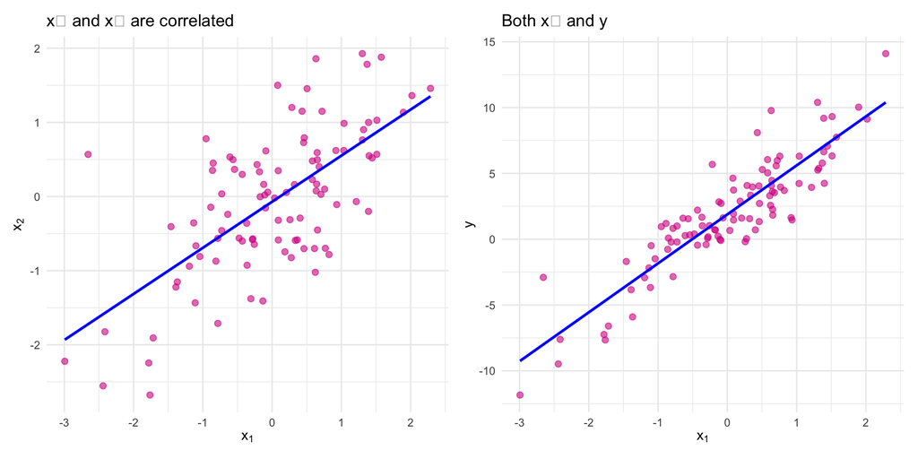

**Problem:** Simple regression of $y$ on $x_1$ confounds the effects of $x_1$ and $x_2$

## The FWL Approach: Step 1

**Step 1:** Regress $y$ on $X_2$ and save residuals $\tilde{y}$

```r
# Regress y on x2
model_y <- lm(y ~ x2)
y_resid <- residuals(model_y)
```

**Interpretation:** $\tilde{y}$ is the part of $y$ that $x_2$ cannot explain

## The FWL Approach: Step 2

**Step 2:** Regress $X_1$ on $X_2$ and save residuals $\tilde{X}_1$

```r
# Regress x1 on x2
model_x1 <- lm(x1 ~ x2)
x1_resid <- residuals(model_x1)
```

**Interpretation:** $\tilde{x}_1$ is the part of $x_1$ that $x_2$ cannot explain

## The FWL Approach: Step 3

**Step 3:** Regress $\tilde{y}$ on $\tilde{X}_1$

```r
# Regress residualized y on residualized x1
model_resid <- lm(y_resid ~ x1_resid)
```

**Result:** The coefficient equals $\hat{\beta}_1$ from the full model!

## Verification

```r
# Compare coefficients
data.frame(
  Method = c("Full regression", "FWL approach"),
  Coefficient = c(coef(model_full)[2], coef(model_resid)[2])
)
```

```
                  Method Coefficient
x1       Full regression    2.688481
x1_resid    FWL approach    2.688481
```

**They are identical!**

## Visualizing FWL

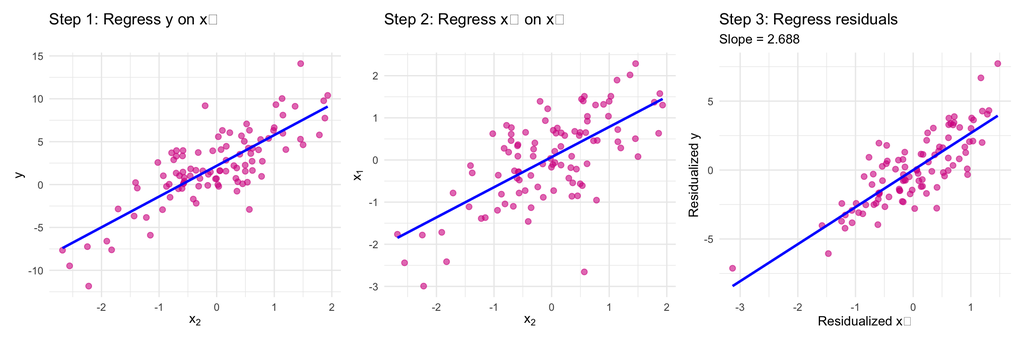

The slope in Step 3 equals $\hat{\beta}_1$ from the full regression

# Mathematical Proof of the Frisch-Waugh-Lovell Theorem

## The Residual Maker Matrix

**Definition:**
$$M_2 = I - X_2(X_2^TX_2)^{-1}X_2^T$$

This is the matrix that creates residuals when you regress something on $X_2$

## What Does $M_2$ Do?

When you regress any variable $z$ on $X_2$, the residuals are:
$$\text{residuals} = z - X_2(X_2^TX_2)^{-1}X_2^Tz = M_2z$$

**Examples:** - $\tilde{y} = M_2 y$ (residuals from regressing $y$ on $X_2$) - $\tilde{X}_1 = M_2 X_1$ (residuals from regressing $X_1$ on $X_2$)

## Understanding the Residual Maker

**Geometric interpretation:** $M_2$ projects onto the space orthogonal to $X_2$

$M_2$ removes the part of any variable that can be explained by $X_2$, leaving only the part that is uncorrelated with $X_2$

## Properties of $M_2$

**Symmetric:** $M_2^T = M_2$

**Idempotent:** $M_2^2 = M_2$

Getting residuals from residuals gives the same residuals

## The FWL Coefficient

Regress $\tilde{y}$ on $\tilde{X}_1$:
$$\hat{\beta}_1^{FWL} = (\tilde{X}_1^T\tilde{X}_1)^{-1}\tilde{X}_1^T\tilde{y}$$

Substitute $\tilde{X}_1 = M_2X_1$ and $\tilde{y} = M_2y$:
$$\hat{\beta}_1^{FWL} = [(M_2X_1)^T(M_2X_1)]^{-1}(M_2X_1)^T(M_2y)$$

## Simplify Using $M_2^T = M_2$

Expand the transpose:
$$\hat{\beta}_1^{FWL} = (X_1^TM_2^TM_2X_1)^{-1}X_1^TM_2^TM_2y$$

Since $M_2$ is symmetric, $M_2^T = M_2$:
$$\hat{\beta}_1^{FWL} = (X_1^TM_2M_2X_1)^{-1}X_1^TM_2M_2y$$

## Simplify Using $M_2^2 = M_2$

$$\hat{\beta}_1^{FWL} = (X_1^TM_2M_2X_1)^{-1}X_1^TM_2M_2y$$

Since $M_2$ is idempotent, $M_2M_2 = M_2$:
$$\hat{\beta}_1^{FWL} = (X_1^TM_2X_1)^{-1}X_1^TM_2y$$

## The Full Regression Coefficient

From the partitioned regression formula (normal equations):
$$\hat{\beta}_1 = (X_1^TM_2X_1)^{-1}X_1^TM_2y$$

**The formulas are identical!**
$$\hat{\beta}_1^{FWL} = \hat{\beta}_1 \quad \checkmark$$

## Intuition: What This Means

Both procedures measure the same thing: the relationship between $X_1$ and $y$ **after accounting for $X_2$**

**FWL approach:** Remove $X_2$’s influence first, then find relationship

**Full regression:** Find all relationships simultaneously

## Intuition: Partial Effects

$\hat{\beta}_1$ = effect of $X_1$ on $y$ **holding $X_2$ constant**

FWL shows this equals: correlation between parts of $X_1$ and $y$ that are **uncorrelated with $X_2$**

# Applications of FWL

## Application 1: Interpreting Controls

**Common statement:** “We control for $X_2$”

**FWL interpretation:** We estimate the effect of the part of $X_1$ that is orthogonal to $X_2$

**Example:** Effect of education on wages, controlling for experience

- We’re looking at variation in education that is *not* explained by experience
- And its relationship with the part of wages *not* explained by experience

## Application 2: Added Variable Plots

**Added variable plots** (also called partial regression plots) visualize the FWL theorem

**Construction:**

1. Residualize $y$ against all controls
2. Residualize the variable of interest against all controls
3. Plot these residuals against each other

**Result:** The slope of this plot is the coefficient from the full regression

## Added Variable Plot Example

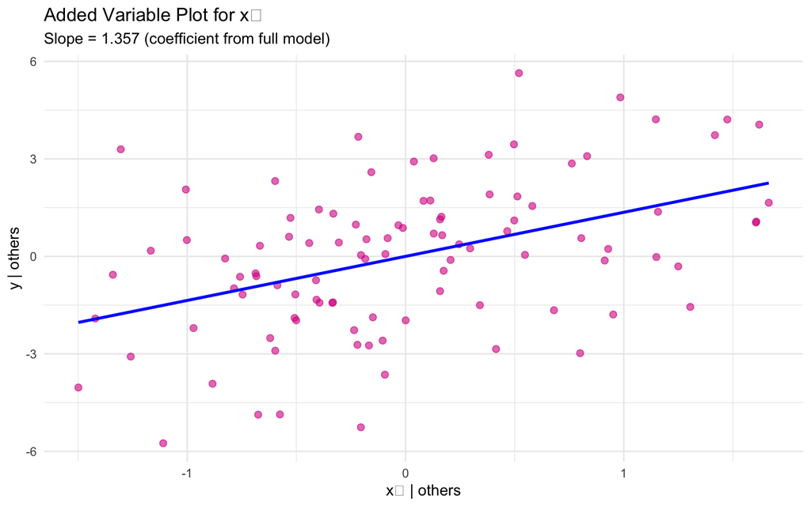

## Application 3: Fixed Effects

**Fixed effects models** are a direct application of FWL

Model with individual fixed effects:
$$y_{it} = \alpha_i + X_{it}\beta + \varepsilon_{it}$$

**FWL approach:** Demean everything within each individual
$$\tilde{y}_{it} = y_{it} - \bar{y}_i, \quad \tilde{X}_{it} = X_{it} - \bar{X}_i$$

## Application 3: Fixed Effects

Then regress $\tilde{y}$ on $\tilde{X}$ to get $\hat{\beta}$

## Fixed Effects Example

```r
# Panel data example
set.seed(456)
n_individuals <- 20
n_time <- 5
id <- rep(1:n_individuals, each = n_time)
time <- rep(1:n_time, times = n_individuals)

# Individual fixed effects
alpha <- rnorm(n_individuals, mean = 5, sd = 2)
alpha_i <- rep(alpha, each = n_time)

# Generate data
x <- rnorm(n_individuals * n_time, mean = 10, sd = 3)
y <- alpha_i + 2*x + rnorm(n_individuals * n_time, sd = 1)

# Method 1: Include dummy variables
model_dummies <- lm(y ~ x + factor(id))

# Method 2: FWL with demeaning
data_panel <- data.frame(id = id, y = y, x = x)
data_panel$y_dm <- ave(y, id, FUN = function(z) z - mean(z))
data_panel$x_dm <- ave(x, id, FUN = function(z) z - mean(z))
model_demeaned <- lm(y_dm ~ x_dm - 1, data = data_panel)

# Compare
data.frame(
  Method = c("With dummies", "Demeaned (FWL)"),
  Coefficient = c(coef(model_dummies)[2], coef(model_demeaned)[1])
)
```

```
             Method Coefficient
x      With dummies    1.998879
x_dm Demeaned (FWL)    1.998879
```

**Both methods give the same coefficient!**

## Application 4: Omitted Variable Bias

**FWL helps us understand omitted variable bias**

Suppose the true model is:
$$y = X_1\beta_1 + X_2\beta_2 + \varepsilon$$

But we only estimate:
$$y = X_1\beta_1 + u$$

## Omitted Variable Bias Formula

**Biased regression estimate:**
$$\hat{\beta}_1^{\text{bias}} = (X_1^TX_1)^{-1}X_1^Ty$$

**Bias:**
$$E[\hat{\beta}_1^{\text{bias}}] = \beta_1 + (X_1^TX_1)^{-1}X_1^TX_2\beta_2$$

## Omitted Variable Bias Formula

**FWL insight:** The bias depends on:

1. How $X_1$ and $X_2$ are related: $(X_1^TX_1)^{-1}X_1^TX_2$
2. The true effect of the omitted variable: $\beta_2$

## Visualizing Omitted Variable Bias

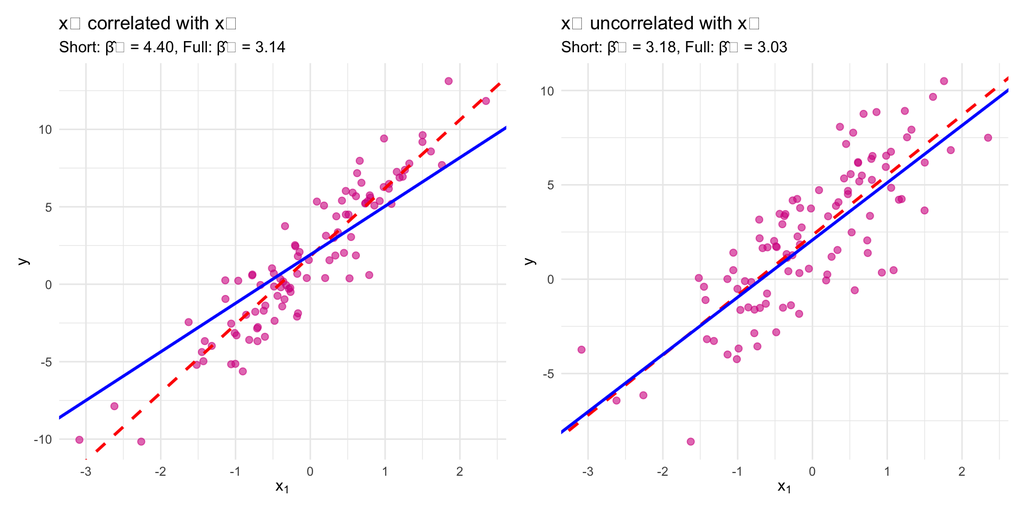

**Left:** Omitting $x_2$ biases $\hat{\beta}_1$ because $x_1$ and $x_2$ are correlated

**Right:** No bias because $x_1$ and $x_2$ are uncorrelated

## Application 5: Computational Efficiency

**Problem:** Large number of controls (e.g., many fixed effects)

**Solution:** Use FWL to avoid inverting huge matrices

## Application 5: Computational Efficiency

Instead of:
$$\hat{\beta} = (X^TX)^{-1}X^Ty$$
where $X$ has many columns

Use FWL to focus on the variables of interest after partialing out the controls

# Properties and Extensions

## FWL Works for Multiple Variables

**Generalization:** FWL works when $X_1$ contains multiple variables

If we want coefficients on several variables after controlling for others:
$$y = X_1\beta_1 + X_2\beta_2 + \varepsilon$$

## FWL Works for Multiple Variables

All of $\hat{\beta}_1$ can be obtained by:

1. Residualize $y$ on $X_2$
2. Residualize each column of $X_1$ on $X_2$
3. Regress residualized $y$ on residualized $X_1$

## FWL and Orthogonality

**Key insight:** FWL creates orthogonality

After residualizing, $\tilde{X}_1$ is orthogonal to $X_2$:
$$\tilde{X}_1^TX_2 = (M_2X_1)^TX_2 = X_1^TM_2^TX_2 = 0$$

**Implication:** In the residualized regression, there’s no confounding between $\tilde{X}_1$ and $X_2$

## FWL and Standard Errors

**Important:** FWL gives correct coefficient estimates but NOT correct standard errors

**Why?** The residualized regression uses $n$ observations but we’ve already “used up” degrees of freedom estimating $X_2$’s effects

**Solution:** Always use the full regression for inference

**Use FWL for:** Understanding, visualization, and computation

**Use full regression for:** Hypothesis tests and confidence intervals

## Standard Error Example

```r
# Full regression
full <- lm(y ~ x1 + x2)

# FWL regression
y_resid <- residuals(lm(y ~ x2))
x1_resid <- residuals(lm(x1 ~ x2))
fwl <- lm(y_resid ~ x1_resid)

# Compare
data.frame(
  Method = c("Full", "FWL"),
  Coefficient = c(coef(full)[2], coef(fwl)[2]),
  SE = c(summary(full)$coefficients[2, 2],
         summary(fwl)$coefficients[2, 2])
)
```

```
         Method Coefficient        SE
x1         Full  -0.2498421 0.6392861
x1_resid    FWL  -0.2498421 0.6360161
```

**Coefficient is identical, but SE differs!**